Tholonia - 510-A-About_This_Book  
The Existential Mechanics of Awareness  
Duncan Stroud  
Published: January 15, 2020  
Updated: Updated: Jan 1, 2026  
Welkin Wall Publishing  
ISBN-10:  
ISBN-13: 978-1-6780-2532-8  
Copyright ©2020 Duncan Stroud CC BY-NC-SA 4.0

This book is an open sourced book. This means that anyone can contribute changes or updates. Instructions and more information at https://tholonia.github.io/the-book (or contact the author at duncan.stroud@gmail.com). This book and its on-line version are distributed under the terms of the Creative Commons Attribution-Noncommercial-ShareAlike 4.0 International (CC BY-NC-SA 4.0) license, with the additional proviso that the right to publish it on paper for sale or other for-profit use is reserved to Duncan Stroud and authorized agents thereof. A reference copy of this license may be found at https://creativecommons.org/licenses/by-nc-sa/4.0/. The above terms include the following: Attribution - you must give appropriate credit, provide a link to the license, and indicate if changes were made. You may do so in any reasonable manner, but not in any way that suggests the licensor endorses you or your use. Noncommercial - You may not use the material for commercial purposes. Share Alike - If you remix, transform, or build upon the material, you must distribute your contributions under the same license as the original. No additional restrictions - you may not apply legal terms or technological measures that legally restrict others from doing anything the license permits. Notices - You do not have to comply with the license for elements of the material in the public domain or where your use is permitted by an applicable exception or limitation. No warranties are given. The license may not give you all of the permissions necessary for your intended use. For example, other rights such as publicity, privacy, or moral rights may limit how you use the material.

# Part IV

Supplementary info, appendices, notes, arguments, analysis, examples, and miscellaneous.

# Appendix A: About This Book

###### Technical information the reader may want to know

## Writing Style

While it is customary to spell out numbers in a sentence, for the most part, numbers in a sentence will be shown as numerals when they refer to a quantity, e.g., “There is 1 apple” vs. “Alone with one’s thoughts”. This allows quantitative values to be easily recognized, increasing text processing efficiency. This style also avoids the inconsistent and differing rules for when it is proper to spell out numbers, such as: any number less than 10, 13, 100; always at the beginning of a sentence; never in dates, days, times, decimals, money, titles, percentages, etc. The general rule in writing is “when in doubt, spell it out”, but there is no doubt with the rule “If it’s a unit of measure in any dimension (time, value, length, quantity, ratio, etc.), it’s a numeral”.

When it comes to the capitalization of the names of celestial objects, which remains a highly unsettled debate, this book follows the recommendation of the American Physical Society (APS). It capitalizes all non-generic references, for example, “Our Universe, Sun, and Moon are instances of many universes, suns, and moons”.

## Low-Tech Issues

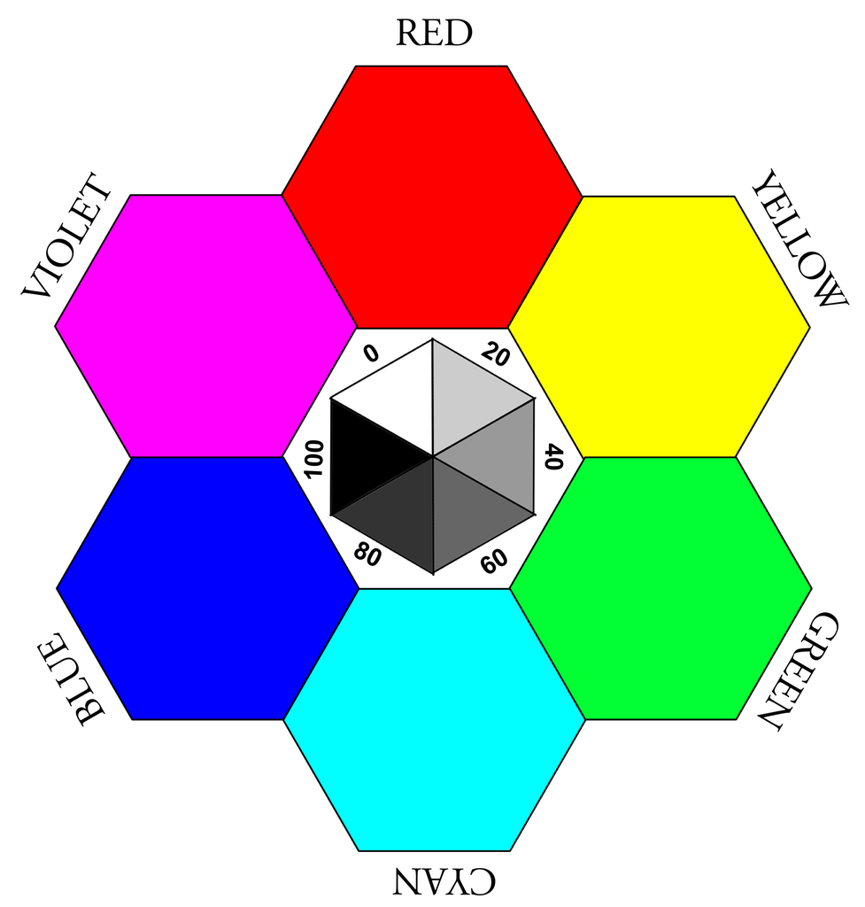

My apologies for the sometimes crude layout of the book in general. Once upon a time, I was a young typographer back in the days when the job often included remelting lead “pigs” used to set type on the Linotype machines of the day. That drudgery has been replaced with endlessly tweaking semi-compatible markup languages such as Markdown, LaTeX, PDF, HTML, CSS, and JavaScript (I was much better at melting “pigs”).

One of the challenges in writing this book was making color images appear meaningful on black-and-white e-book readers. In some cases, it was not possible, especially since different ebook readers use different schemes to handle colors.

To that end, here is a simple color wheel showing how your e-reader treats at least the 6 basic colors. The center shows the 6 shades of white to black.

The sad and current state of ebook readers is that most do not support anything but the most basic formatting, and even *that* is often spotty, especially regarding blockquotes and lists, and even more so if the e-reader is older. Using color is discouraged for ebook publishers, but it is necessary for this book. Feel free to download the latest version in color PDF from https://tholonia.com.

If you are reading this on an e-book reader, the chances that it will look especially ugly are quite high. This is because many ebook reader manufacturers deliberately eliminate the author’s layout and replace it with their own generic (and, IMHO, hideous) one-size-fits-all format. The only upside I can imagine is for the manufacturer, as it frees them from dealing with more complex layouts. I find this practice offensive to the author and the reader, not to mention reinforcing the standards of banality. There are ways around this, but it involves downloading software and installing patches on the ebook reader.

[^1]: Johnson, R. L., Bui, B., and Schmitt, L. L. “**Are Two Spaces Better Than One? The Effect of Spacing Following Periods and Commas During Reading**”. *Attention, Perception, & Psychophysics*, vol. 80, no. 6, 2018, pp. 1504-1511. DOI: 10.3758/s13414-018-1527-6